# MLDS

Libraries

```r
library(car)
library(caret)
library(randomForest)
library(tidyverse)
```

We cleaned the data in another RMD document, and we will be using the cleaned dataset here.

Get Data

```r
hosp <- read.csv("C:\\Users\\Rakib Kamal\\Documents\\GitHub\\FinalProject\\sample for ml.csv")
```

Facotorize and adjust varaibles:

```r
hosp <- hosp %>% mutate(ED=ifelse(ED=="Y", 1, 0))
hosp$Severity.Code <- as.numeric(as.factor(hosp$Severity.Code))
hosp$MDC.Code <- as.numeric(as.factor(hosp$MDC.Code))
hosp$Duration <- as.numeric(as.factor(hosp$Duration))
```

Test/Train Split: We added a sampleTrain dataframe as 10% of our sample due to computational limitations from training the Random Forest Model. We will only use it for Random Forests

```r
set.seed(101)
index <- createDataPartition(hosp$Charges,p = 0.8, list = FALSE)
train <- hosp[index,]
test <- hosp[-index,]

sampleIndex <- createDataPartition(train$Charges,p = 0.1, list = FALSE)
sampleTrain <- train[sampleIndex,]
```

Multiple Linear Model and K-fold cross validation: We chose to remove some varaibles due to multicollinearity, in which we determined that these values are multicollinear using the vif() and alias() functions.

```r
features <- train %>%
  select(-"Age", -"Abortion", -"CCS.Procedure", -"CCS.Diagnosis", -"DRG", -"MDC", -"County", -"Payment2", -"Payment3", -"Discharge.Status", -"Severity", "Severity.Code", -"Area", -"CCS.Procedure.Group", -"drg.group", -"if.birth", -"na.payment1", -"numpay")
regressCntrl <- trainControl(method = "cv", number = 10)
fit <- train(Charges~., data=features, method="lm", trControl=regressCntrl, na.action=na.omit)
data.frame(MultipleRSquared = summary(fit)$r.squared[1],
           AdjustedRSquared = summary(fit)$adj.r.squared[1],
           FStatistic = summary(fit)$fstatistic[1])
```

```
##       MultipleRSquared AdjustedRSquared FStatistic
## value        0.8711267        0.8709516   4973.501
```

```r
##vvv <- lm(Charges~., data=dumbo)
#attributes(alias(vvv)$Complete)$dimnames
#alias(vvv)
#vif(vvv)
```

Predictions from linear model

```r
predictions <- fit %>% predict(test)

data.frame( R2 = R2(predictions, test$Charges),
            RMSE = RMSE(predictions, test$Charges))
```

```
##          R2     RMSE
## 1 0.8191223 69430.29
```

We will attempt to improve this model by using Random Forests to determine varaible importance

```r
features <- sampleTrain %>% select(-"Age", -"Abortion", -"CCS.Procedure", -"CCS.Diagnosis", -"DRG", -"MDC", -"County", -"Payment2", -"Payment3", -"Discharge.Status", -"Severity", "Severity.Code", -"Area", -"CCS.Procedure.Group", -"drg.group", -"if.birth", -"na.payment1", -"numpay")
fit <- randomForest(Charges~., data=features,
                     importance=T)
varImp(fit)
```

```
##                            Overall
## Zip                      0.6948398
## Facility.ID              4.7844046
## Gender                  -1.5944722
## Race                     1.4634836
## Ethnicity                1.3535167
## Duration                16.7568166
## Type                    -0.8815641
## CCS.Code                 0.6325592
## CCS.Procedure.Code       1.4437758
## DRG.Code                 2.4139117
## MDC.Code                 0.8101345
## Severity.Code           -0.7523133
## Mortality.Risk           2.9364278
## Surgical                 1.0977773
## Payment1                 0.9821237
## Birthweight              1.5283406
## ED                       0.2660788
## Costs                   24.1766750
## birthweight.cat          2.4625020
## chargeratio             10.2921005
## Median.Household.Income  2.7814742
## selfpay                  3.8037467
## Median.Income..family.  -0.1737739
## redacted                 0.0000000
## na.zip                   0.0000000
## invalid.drg              0.0000000
## no.payment2              0.0000000
## unknown.payment2         0.1027596
## no.payment3              0.0000000
## unknown.payment3         1.5400700
## na.gender                0.0000000
## na.ethnicity             0.0000000
## na.surgical              0.0000000
## high.id                  3.6764566
## na.type                  0.0000000
## na.discharge             0.0000000
## na.ccs                   0.0000000
## na.ccs.procedure         0.0000000
## na.mdc                   0.0000000
```

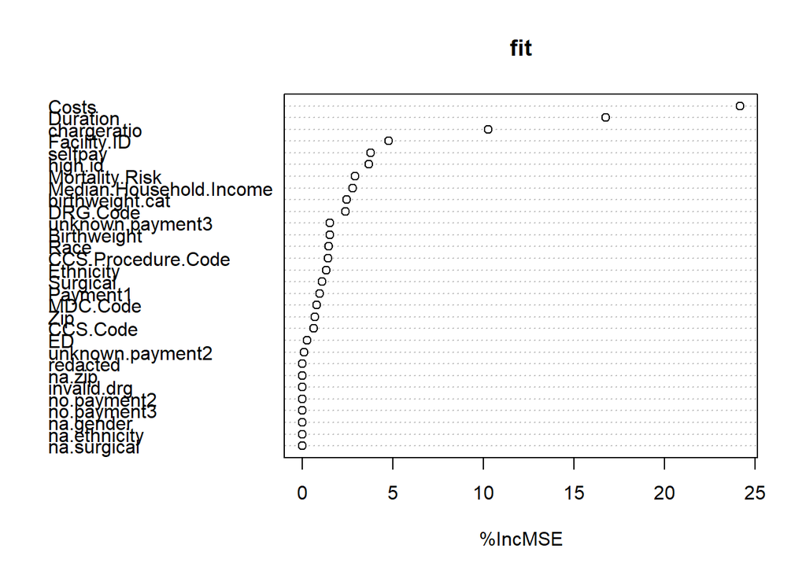

```r
varImpPlot(fit, type=1)
```

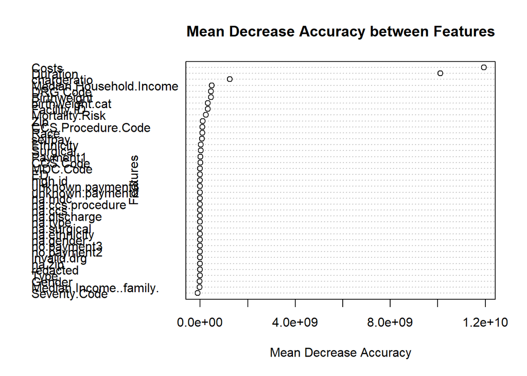

```r
impToPlot <- importance(fit, scale = FALSE)
dotchart(sort(impToPlot[,1]), xlab = "Mean Decrease Accuracy", ylab="Features", main = "Mean Decrease Accuracy between Features")
```

Predictions with the Random Forest Model

```r
predictions <- fit %>% predict(test)
data.frame( R2 = R2(predictions, test$Charges),
            RMSE = RMSE(predictions, test$Charges))
```

```
##          R2     RMSE
## 1 0.8075028 74510.72
```

Selective Multiple Linear Regression Model

```r
regressCntrl <- trainControl(method = "cv", number = 10)
fit <- train(Charges~Costs+Duration+Birthweight+Severity.Code+DRG.Code+Mortality.Risk+Facility.ID+birthweight.cat, data=train, method="lm", trControl=regressCntrl, na.action=na.omit)

predictions <- fit %>% predict(test)
data.frame(MultipleRSquared = summary(fit)$r.squared[1],
           AdjustedRSquared = summary(fit)$adj.r.squared[1],
           FStatistic = summary(fit)$fstatistic[1])
```

```
##       MultipleRSquared AdjustedRSquared FStatistic
## value         0.867907        0.8678581   17743.43
```

Predictions for Selective Multiple Linear Regression Model

```r
data.frame( R2 = R2(predictions, test$Charges),
            RMSE = RMSE(predictions, test$Charges))
```

```
##          R2     RMSE
## 1 0.8155615 70098.66
```